# Untitled

# 2. when you work with data, you need to make sure that you examine the variables for outliers and incorrectly coded/entered values. But now, you’re ready for regression analysis.

## a. use the `lm` command to run the regression where LNMEDHVAL is the dependent variable and PCTVACANT, PCTSINGLES, PCTBACHMOR, and LNNBELPOV100 are predictors.

```r
# Assuming reg_data is your data frame containing the variables
# Run the linear regression
model <- lm(LNMEDHVAL ~ PCTVACANT + PCTSINGLES + PCTBACHMOR + LNNBELPOV, data = PhillyData_1)

# Display the summary of the regression model
summary(model)
```

```
##
## Call:
## lm(formula = LNMEDHVAL ~ PCTVACANT + PCTSINGLES + PCTBACHMOR +
##     LNNBELPOV, data = PhillyData_1)
##
## Residuals:
##      Min       1Q   Median       3Q      Max
## -2.25817 -0.20391  0.03822  0.21743  2.24345
##
## Coefficients:
##               Estimate Std. Error t value Pr(>|t|)
## (Intercept) 11.1137781  0.0465318 238.843  < 2e-16 ***
## PCTVACANT   -0.0191563  0.0009779 -19.590  < 2e-16 ***
## PCTSINGLES   0.0029770  0.0007032   4.234 2.42e-05 ***
## PCTBACHMOR   0.0209095  0.0005432  38.494  < 2e-16 ***
## LNNBELPOV   -0.0789035  0.0084567  -9.330  < 2e-16 ***
## ---
## Signif. codes:  0 '***' 0.001 '**' 0.01 '*' 0.05 '.' 0.1 ' ' 1
##
## Residual standard error: 0.3665 on 1715 degrees of freedom
## Multiple R-squared:  0.6623, Adjusted R-squared:  0.6615
## F-statistic: 840.9 on 4 and 1715 DF,  p-value: < 2.2e-16
```

## b. , be sure to present the summary of the fit as well as the ANOVA table containing the regression and error sum of squares (use the summary and anova commands).

```r
anova(model)
```

```
## Analysis of Variance Table
##
## Response: LNMEDHVAL
##              Df  Sum Sq Mean Sq  F value    Pr(>F)
## PCTVACANT     1 180.383 180.383 1343.093 < 2.2e-16 ***
## PCTSINGLES    1  24.543  24.543  182.741 < 2.2e-16 ***
## PCTBACHMOR    1 235.111 235.111 1750.586 < 2.2e-16 ***
## LNNBELPOV     1  11.692  11.692   87.054 < 2.2e-16 ***
## Residuals  1715 230.332   0.134
## ---
## Signif. codes:  0 '***' 0.001 '**' 0.01 '*' 0.05 '.' 0.1 ' ' 1
```

## c. Use the fitted, residuals and rstandard commands to save the predicted values, residuals and standardized residuals, respectively.

```r
PhillyData_1$resids <- residuals(model)
PhillyData_1$predvals <- fitted(model)
PhillyData_1$stdres <- rstandard(model)
```

## d. Create a scatter plot with Standardized Residuals on the y-axis and Predicted Values on the x-axis. You will be asked to present this scatter plot in your report, so take a screenshot of it if you plan to use MS Word.

```r
#plot(PhillyData$predvals, PhillyData$stdres)
```

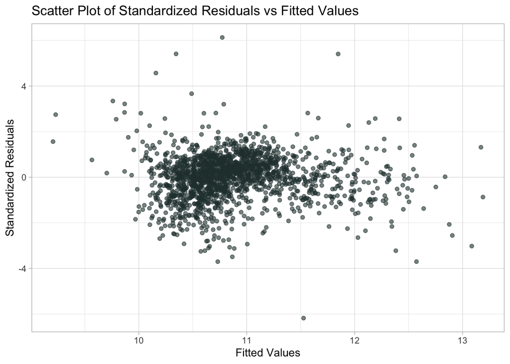

```r
ggplot(PhillyData_1, aes(x = predvals, y = stdres)) +
  geom_point(color = "#283d3b", alpha = 0.6) +    # Scatter plot points
  labs(
    title = "Scatter Plot of Standardized Residuals vs Fitted Values",
    x = "Fitted Values",
    y = "Standardized Residuals"
  ) +
  theme_light()
```

# 3. step$anova output

```r
stepwise_model <- step(model, direction = "both", trace = 0)  # 'trace = 0' suppresses detailed output
#summary(stepwise_model)
stepwise_anova <- stepwise_model$anova
stepwise_anova
```

```
##   Step Df Deviance Resid. Df Resid. Dev       AIC
## 1      NA       NA      1715   230.3317 -3448.162
```

```r
step <- stepAIC(model, direction="both")
```

```
## Start:  AIC=-3448.16
## LNMEDHVAL ~ PCTVACANT + PCTSINGLES + PCTBACHMOR + LNNBELPOV
##
##              Df Sum of Sq    RSS     AIC
## <none>                    230.33 -3448.2
## - PCTSINGLES  1     2.407 232.74 -3432.3
## - LNNBELPOV   1    11.692 242.02 -3365.0
## - PCTVACANT   1    51.543 281.87 -3102.8
## - PCTBACHMOR  1   199.014 429.35 -2379.0
```

```r
step$anova
```

```
## Stepwise Model Path
## Analysis of Deviance Table
##
## Initial Model:
## LNMEDHVAL ~ PCTVACANT + PCTSINGLES + PCTBACHMOR + LNNBELPOV
##
## Final Model:
## LNMEDHVAL ~ PCTVACANT + PCTSINGLES + PCTBACHMOR + LNNBELPOV
##
##
##   Step Df Deviance Resid. Df Resid. Dev       AIC
## 1                       1715   230.3317 -3448.162
```